# Binary Classification Model for [Project Name] Using R version 07

## 3. Prepare Data

Some dataset may require additional preparation activities that will best exposes the structure of the problem and the relationships between the input attributes and the output variable. Some data-prep tasks might include:

- Cleaning data by removing duplicates, marking missing values and even imputing missing values.
- Feature selection where redundant features may be removed.
- Data transforms where attributes are scaled or redistributed in order to best expose the structure of the problem later to learning algorithms.

```r
email_notify(paste("Data Cleaning and Transformation has begun!",date()))
```

```
## [1] "Java-Object{org.apache.commons.mail.SimpleEmail@6d7b4f4c}"
```

### 3.a) Data Cleaning

```r
# Not applicable for this iteration of the project.
# Sample code for performing basic data cleaning tasks

# Mark missing values
#invalid <- 0
#entireDataset$some_col[entireDataset$some_col==invalid] <- NA

# Impute missing values
#entireDataset$some_col <- with(entireDataset, impute(some_col, mean))
```

### 3.b) Feature Selection

```r
# Using the correlations calculated previously, we try to find attributes that are highly correlated.
# highlyCorrelated <- findCorrelation(correlations, cutoff=0.85)
# print(highlyCorrelated)
# cat('Number of attributes found to be highly correlated:',length(highlyCorrelated))

# Removing the highly correlated attributes from the training and validation dataframes
# xy_train <- xy_train[, -highlyCorrelated]
# xy_test <- xy_test[, -highlyCorrelated]
```

```r
# Sample code for performing feature selection by ranking the attributes' importance.
# startTimeModule <- proc.time()
# set.seed(seedNum)
# library(gbm)
# model_fs <- train(targetVar~., data=xy_train, method="gbm", preProcess="scale", trControl=control, verbose=F)
# rankedImportance <- varImp(model_fs, scale=FALSE)
# print(rankedImportance)
# plot(rankedImportance)

# Set the importance threshold and calculate the list of attributes that don't contribute to the importance threshold
# maxThreshold <- 0.99
# rankedAttributes <- rankedImportance$importance
# rankedAttributes <- rankedAttributes[order(-rankedAttributes$Overall),,drop=FALSE]
# totalWeight <- sum(rankedAttributes)
# i <- 1
# accumWeight <- 0
# exit_now <- FALSE
# while ((i <= totAttr) & !exit_now) {
#   accumWeight = accumWeight + rankedAttributes[i,]
#   if ((accumWeight/totalWeight) >= maxThreshold) {
#     exit_now <- TRUE
#   } else {
#     i <- i + 1
#   }
# }
# lowImportance <- rankedAttributes[(i+1):(totAttr),,drop=FALSE]
# lowAttributes <- rownames(lowImportance)
# cat('Number of attributes contributed to the importance threshold:',i,"\n")
# cat('Number of attributes found to be of low importance:',length(lowAttributes))

# Removing the unselected attributes from the training and validation dataframes
# xy_train <- xy_train[, !(names(xy_train) %in% lowAttributes)]
# xy_test <- xy_test[, !(names(xy_test) %in% lowAttributes)]
```

```r
# Sample code for perfoming feature selection using the Recursive Feature Elimination (RFE) technique
# startTimeModule <- proc.time()
# set.seed(seedNum)
# rfeCTRL <- rfeControl(functions=rfFuncs, method="cv", number=10)
# rfeResults <- rfe(xy_train[,1:totAttr], xy_train[,totCol], sizes=c(30:55), rfeControl=rfeCTRL)
# print(rfeResults)
# rfeAttributes <- predictors(rfeResults)
# cat('Number of attributes identified from the RFE algorithm:',length(rfeAttributes))
# print(rfeAttributes)
# plot(rfeResults, type=c("g", "o"))

# Removing the unselected attributes from the training and validation dataframes
# rfeAttributes <- c(rfeAttributes,"targetVar")
# xy_train <- xy_train[, (names(xy_train) %in% rfeAttributes)]
# xy_test <- xy_test[, (names(xy_test) %in% rfeAttributes)]
```

### 3.c) Data Transforms

```r
# Sample code for performing SMOTE transformation to combat the unbalanced data
# set.seed(seedNum)
# xy_train <- SMOTE(targetVar ~., data=xy_train, perc.over=200, perc.under=300)
# totCol <- ncol(xy_train)
# y_train <- xy_train[,totCol]
# cbind(freq=table(y_train), percentage=prop.table(table(y_train))*100)
```

### 3.d) Display the Final Dataset for Model-Building

```r
dim(xy_train)
```

```
## [1] 538   9
```

```r
dim(xy_test)
```

```
## [1] 230   9
```

```r
sapply(xy_train, class)
```

```
##  pregnant   glucose  pressure   triceps   insulin      mass  pedigree
## "numeric" "numeric" "numeric" "numeric" "numeric" "numeric" "numeric"
##       age targetVar
## "numeric"  "factor"
```

```r
email_notify(paste("Data Cleaning and Transformation completed!",date()))
```

```
## [1] "Java-Object{org.apache.commons.mail.SimpleEmail@63753b6d}"
```

```r
proc.time()-startTimeScript
```

```
##    user  system elapsed
##    8.77    7.17   27.00
```

## 4. Model and Evaluate Algorithms

After the data-prep, we next work on finding a workable model by evaluating a subset of machine learning algorithms that are good at exploiting the structure of the training. The typical evaluation tasks include:

- Defining test options such as cross validation and the evaluation metric to use.
- Spot checking a suite of linear and nonlinear machine learning algorithms.
- Comparing the estimated accuracy of algorithms.

For this project, we will evaluate one linear, two non-linear, and three ensemble algorithms:

Linear Algorithm: Logistic Regression

Non-Linear Algorithms: Decision Trees (CART) and k-Nearest Neighbors

Ensemble Algorithms: Bagged CART, Random Forest, and Stochastic Gradient Boosting

The random number seed is reset before each run to ensure that the evaluation of each algorithm is performed using the same data splits. It ensures the results are directly comparable.

### 4.a) Generate models using linear algorithms

```r
# Logistic Regression (Classification)
email_notify(paste("Linear Regression modeling has begun!",date()))
```

```
## [1] "Java-Object{org.apache.commons.mail.SimpleEmail@6c3708b3}"
```

```r
startTimeModule <- proc.time()
set.seed(seedNum)
fit.glm <- train(targetVar~., data=xy_train, method="glm", metric=metricTarget, trControl=control)
print(fit.glm)
```

```
## Generalized Linear Model
##
## 538 samples
##   8 predictor
##   2 classes: 'pos', 'neg'
##
## No pre-processing
## Resampling: Cross-Validated (10 fold, repeated 3 times)
## Summary of sample sizes: 484, 484, 484, 484, 485, 484, ...
## Resampling results:
##
##   Accuracy   Kappa
##   0.7646518  0.4554814
```

```r
proc.time()-startTimeModule
```

```
##    user  system elapsed
##    0.78    0.02    0.79
```

```r
email_notify(paste("Linear Regression modeling completed!",date()))
```

```
## [1] "Java-Object{org.apache.commons.mail.SimpleEmail@57536d79}"
```

### 4.b) Generate models using nonlinear algorithms

```r
# Decision Tree - CART (Regression/Classification)
email_notify(paste("Decision Tree modeling has begun!",date()))
```

```
## [1] "Java-Object{org.apache.commons.mail.SimpleEmail@1f28c152}"
```

```r
startTimeModule <- proc.time()
set.seed(seedNum)
fit.cart <- train(targetVar~., data=xy_train, method="rpart", metric=metricTarget, trControl=control)
print(fit.cart)
```

```
## CART
##
## 538 samples
##   8 predictor
##   2 classes: 'pos', 'neg'
##
## No pre-processing
## Resampling: Cross-Validated (10 fold, repeated 3 times)
## Summary of sample sizes: 484, 484, 484, 484, 485, 484, ...
## Resampling results across tuning parameters:
##
##   cp          Accuracy   Kappa
##   0.02393617  0.7410669  0.39768886
##   0.08510638  0.7150943  0.37047691
##   0.25000000  0.6543326  0.06809686
##
## Accuracy was used to select the optimal model using the largest value.
## The final value used for the model was cp = 0.02393617.
```

```r
proc.time()-startTimeModule
```

```
##    user  system elapsed
##    1.01    0.03    1.09
```

```r
email_notify(paste("Decision Tree modeling completed!",date()))
```

```
## [1] "Java-Object{org.apache.commons.mail.SimpleEmail@67b92f0a}"
```

```r
# k-Nearest Neighbors (Regression/Classification)
email_notify(paste("k-Nearest Neighbors modeling has begun!",date()))
```

```
## [1] "Java-Object{org.apache.commons.mail.SimpleEmail@887af79}"
```

```r
startTimeModule <- proc.time()
set.seed(seedNum)
fit.knn <- train(targetVar~., data=xy_train, method="knn", metric=metricTarget, trControl=control)
print(fit.knn)
```

```
## k-Nearest Neighbors
##
## 538 samples
##   8 predictor
##   2 classes: 'pos', 'neg'
##
## No pre-processing
## Resampling: Cross-Validated (10 fold, repeated 3 times)
## Summary of sample sizes: 484, 484, 484, 484, 485, 484, ...
## Resampling results across tuning parameters:
##
##   k  Accuracy   Kappa
##   5  0.7051363  0.3445008
##   7  0.7118798  0.3555127
##   9  0.7206266  0.3712855
##
## Accuracy was used to select the optimal model using the largest value.
## The final value used for the model was k = 9.
```

```r
proc.time()-startTimeModule
```

```
##    user  system elapsed
##    0.83    0.02    0.85
```

```r
email_notify(paste("k-Nearest Neighbors modeling completed!",date()))
```

```
## [1] "Java-Object{org.apache.commons.mail.SimpleEmail@23e028a9}"
```

### 4.c) Generate models using ensemble algorithms

In this section, we will explore the use and tuning of ensemble algorithms to see whether we can improve the results.

```r
# Bagged CART (Regression/Classification)
email_notify(paste("Bagged CART modeling has begun!",date()))
```

```
## [1] "Java-Object{org.apache.commons.mail.SimpleEmail@3701eaf6}"
```

```r
startTimeModule <- proc.time()
set.seed(seedNum)
fit.bagcart <- train(targetVar~., data=xy_train, method="treebag", metric=metricTarget, trControl=control)
print(fit.bagcart)
```

```
## Bagged CART
##
## 538 samples
##   8 predictor
##   2 classes: 'pos', 'neg'
##
## No pre-processing
## Resampling: Cross-Validated (10 fold, repeated 3 times)
## Summary of sample sizes: 484, 484, 484, 484, 485, 484, ...
## Resampling results:
##
##   Accuracy   Kappa
##   0.7398672  0.4154009
```

```r
proc.time()-startTimeModule
```

```
##    user  system elapsed
##    5.73    0.01    5.79
```

```r
email_notify(paste("Bagged CART modeling completed!",date()))
```

```
## [1] "Java-Object{org.apache.commons.mail.SimpleEmail@551aa95a}"
```

```r
# Random Forest (Regression/Classification)
email_notify(paste("Random Forest modeling has begun!",date()))
```

```
## [1] "Java-Object{org.apache.commons.mail.SimpleEmail@3cef309d}"
```

```r
startTimeModule <- proc.time()
set.seed(seedNum)
fit.rf <- train(targetVar~., data=xy_train, method="rf", metric=metricTarget, trControl=control)
print(fit.rf)
```

```
## Random Forest
##
## 538 samples
##   8 predictor
##   2 classes: 'pos', 'neg'
##
## No pre-processing
## Resampling: Cross-Validated (10 fold, repeated 3 times)
## Summary of sample sizes: 484, 484, 484, 484, 485, 484, ...
## Resampling results across tuning parameters:
##
##   mtry  Accuracy   Kappa
##   2     0.7572327  0.4470429
##   5     0.7516422  0.4395832
##   8     0.7460401  0.4285037
##
## Accuracy was used to select the optimal model using the largest value.
## The final value used for the model was mtry = 2.
```

```r
proc.time()-startTimeModule
```

```
##    user  system elapsed
##   20.12    0.76   20.93
```

```r
email_notify(paste("Random Forest modeling completed!",date()))
```

```
## [1] "Java-Object{org.apache.commons.mail.SimpleEmail@7494e528}"
```

```r
# Stochastic Gradient Boosting (Regression/Classification)
email_notify(paste("Stochastic Gradient Boosting modeling has begun!",date()))
```

```
## [1] "Java-Object{org.apache.commons.mail.SimpleEmail@5e853265}"
```

```r
startTimeModule <- proc.time()
set.seed(seedNum)
fit.gbm <- train(targetVar~., data=xy_train, method="gbm", metric=metricTarget, trControl=control, verbose=F)
print(fit.gbm)
```

```
## Stochastic Gradient Boosting
##
## 538 samples
##   8 predictor
##   2 classes: 'pos', 'neg'
##
## No pre-processing
## Resampling: Cross-Validated (10 fold, repeated 3 times)
## Summary of sample sizes: 484, 484, 484, 484, 485, 484, ...
## Resampling results across tuning parameters:
##
##   interaction.depth  n.trees  Accuracy   Kappa
##   1                   50      0.7659329  0.4546808
##   1                  100      0.7671908  0.4636871
##   1                  150      0.7572327  0.4467056
##   2                   50      0.7634521  0.4556167
##   2                  100      0.7504426  0.4327444
##   2                  150      0.7430002  0.4167499
##   3                   50      0.7645819  0.4610347
##   3                  100      0.7484976  0.4284272
##   3                  150      0.7367342  0.4047840
##
## Tuning parameter 'shrinkage' was held constant at a value of 0.1
##
## Tuning parameter 'n.minobsinnode' was held constant at a value of 10
## Accuracy was used to select the optimal model using the largest value.
## The final values used for the model were n.trees = 100,
##  interaction.depth = 1, shrinkage = 0.1 and n.minobsinnode = 10.
```

```r
proc.time()-startTimeModule
```

```
##    user  system elapsed
##    4.74    0.05    4.80
```

```r
email_notify(paste("Stochastic Gradient Boosting modeling completed!",date()))
```

```
## [1] "Java-Object{org.apache.commons.mail.SimpleEmail@1e6d1014}"
```

### 4.d) Compare baseline algorithms

```r
results <- resamples(list(LR=fit.glm, CART=fit.cart, kNN=fit.knn, BagCART=fit.bagcart, RF=fit.rf, GBM=fit.gbm))
summary(results)
```

```
##
## Call:
## summary.resamples(object = results)
##
## Models: LR, CART, kNN, BagCART, RF, GBM
## Number of resamples: 30
##
## Accuracy
##              Min.   1st Qu.    Median      Mean   3rd Qu.      Max. NA's
## LR      0.5925926 0.7256289 0.7756813 0.7646518 0.8075646 0.8703704    0
## CART    0.5925926 0.7037037 0.7407407 0.7410669 0.7962963 0.8679245    0
## kNN     0.5925926 0.6853599 0.7222222 0.7206266 0.7731481 0.8148148    0
## BagCART 0.5925926 0.7037037 0.7407407 0.7398672 0.7916667 0.8703704    0
## RF      0.5555556 0.7222222 0.7592593 0.7572327 0.8075646 0.8888889    0
## GBM     0.6111111 0.7222222 0.7735849 0.7671908 0.8075646 0.9074074    0
##
## Kappa
##                Min.   1st Qu.    Median      Mean   3rd Qu.      Max. NA's
## LR      -0.01538462 0.3790280 0.4888058 0.4554814 0.5578616 0.7123288    0
## CART     0.01164725 0.3069269 0.3873582 0.3976889 0.5272853 0.7094753    0
## kNN      0.01164725 0.2806782 0.3758682 0.3712855 0.4775377 0.6035242    0
## BagCART  0.10676692 0.3177449 0.4245722 0.4154009 0.5306916 0.7256894    0
## RF      -0.07820300 0.3790280 0.4566583 0.4470429 0.5628381 0.7563910    0
## GBM      0.04384486 0.3993736 0.4738414 0.4636871 0.5405234 0.7945205    0
```

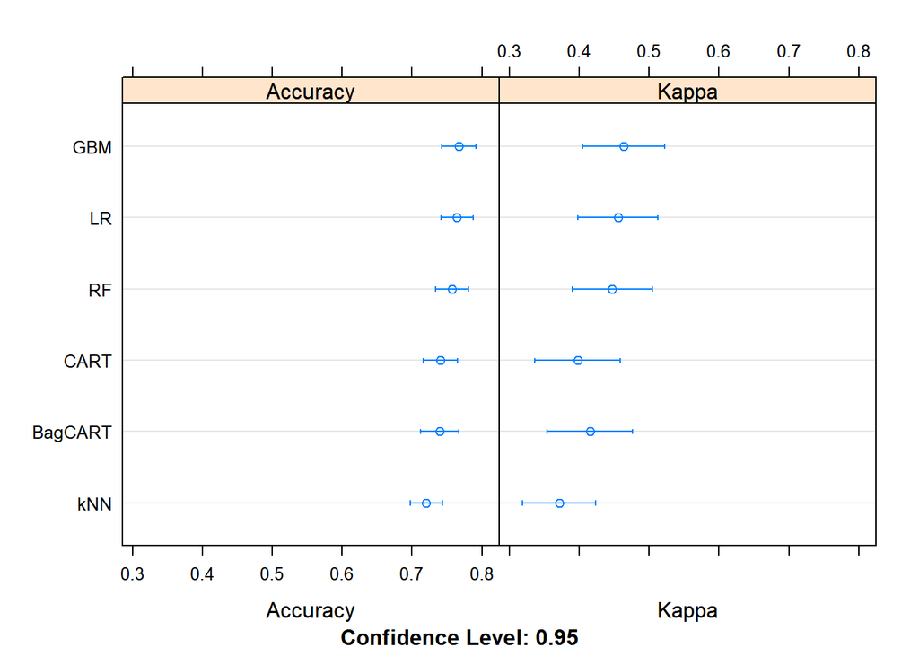

```r
dotplot(results)
```

```r
cat('The average accuracy from all models is:',
    mean(c(results$values$`LR~Accuracy`,results$values$`CART~Accuracy`,results$values$`kNN~Accuracy`,results$values$`BagCART~Accuracy`,results$values$`RF~Accuracy`,results$values$`GBM~Accuracy`)))
```

```
## The average accuracy from all models is: 0.7484393
```

## 5. Improve Accuracy or Results

After we achieve a short list of machine learning algorithms with good level of accuracy, we can leverage ways to improve the accuracy of the models.

### 5.a) Algorithm Tuning

Finally, we will tune the best-performing algorithms from each group further and see whether we can get more accuracy out of them.

```r
# Tuning algorithm #1 - Logistic Regression
# Logistic Regression has no special tuning parameters
email_notify(paste("Algorithm #1 tuning has begun!",date()))
```

```
## [1] "Java-Object{org.apache.commons.mail.SimpleEmail@131276c2}"
```

```r
startTimeModule <- proc.time()
set.seed(seedNum)
fit.final1 <- fit.glm
print(fit.final1)
```

```
## Generalized Linear Model
##
## 538 samples
##   8 predictor
##   2 classes: 'pos', 'neg'
##
## No pre-processing
## Resampling: Cross-Validated (10 fold, repeated 3 times)
## Summary of sample sizes: 484, 484, 484, 484, 485, 484, ...
## Resampling results:
##
##   Accuracy   Kappa
##   0.7646518  0.4554814
```

```r
proc.time()-startTimeModule
```

```
##    user  system elapsed
##    0.01    0.00    0.02
```

```r
email_notify(paste("Algorithm #1 tuning completed!",date()))
```

```
## [1] "Java-Object{org.apache.commons.mail.SimpleEmail@51cdd8a}"
```

```r
# Tuning algorithm #2 - Stochastic Gradient Boosting
email_notify(paste("Algorithm #2 tuning has begun!",date()))
```

```
## [1] "Java-Object{org.apache.commons.mail.SimpleEmail@10bbd20a}"
```

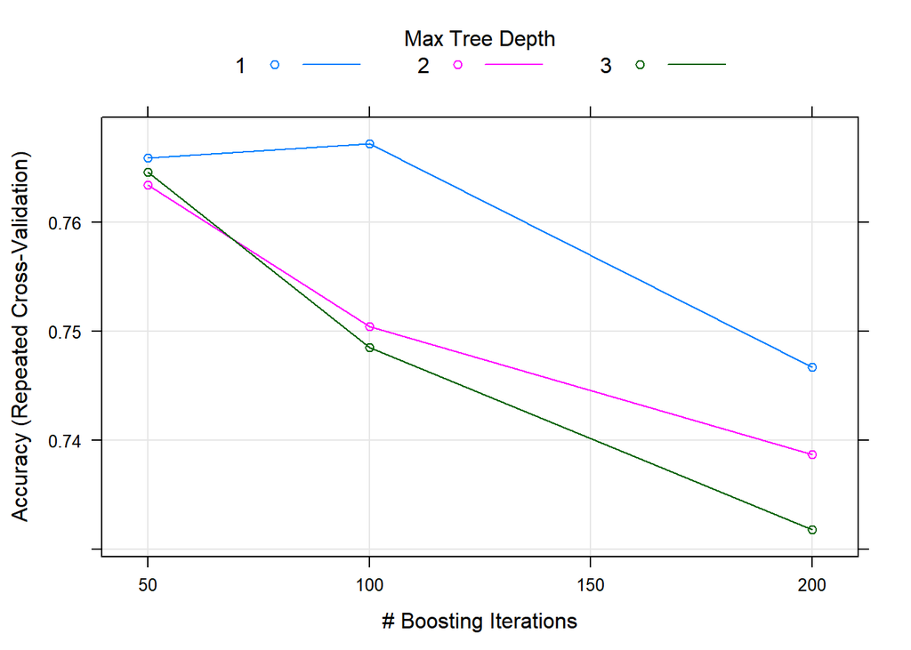

```r
startTimeModule <- proc.time()
set.seed(seedNum)
grid <- expand.grid(.n.trees=c(50, 100, 200), .shrinkage=0.1, .interaction.depth=c(1, 2, 3), .n.minobsinnode=10)
fit.final2 <- train(targetVar~., data=xy_train, method="gbm", metric=metricTarget, tuneGrid=grid, trControl=control, verbose=F)
plot(fit.final2)
```

```r
print(fit.final2)
```

```
## Stochastic Gradient Boosting
##
## 538 samples
##   8 predictor
##   2 classes: 'pos', 'neg'
##
## No pre-processing
## Resampling: Cross-Validated (10 fold, repeated 3 times)
## Summary of sample sizes: 484, 484, 484, 484, 485, 484, ...
## Resampling results across tuning parameters:
##
##   interaction.depth  n.trees  Accuracy   Kappa
##   1                   50      0.7659329  0.4546808
##   1                  100      0.7671908  0.4636871
##   1                  200      0.7467156  0.4211469
##   2                   50      0.7634521  0.4556167
##   2                  100      0.7504426  0.4327444
##   2                  200      0.7386909  0.4028719
##   3                   50      0.7645819  0.4610347
##   3                  100      0.7484976  0.4284272
##   3                  200      0.7317843  0.3974468
##
## Tuning parameter 'shrinkage' was held constant at a value of 0.1
##
## Tuning parameter 'n.minobsinnode' was held constant at a value of 10
## Accuracy was used to select the optimal model using the largest value.
## The final values used for the model were n.trees = 100,
##  interaction.depth = 1, shrinkage = 0.1 and n.minobsinnode = 10.
```

```r
proc.time()-startTimeModule
```

```
##    user  system elapsed
##    5.92    0.02    5.97
```

```r
email_notify(paste("Algorithm #2 tuning completed!",date()))
```

```
## [1] "Java-Object{org.apache.commons.mail.SimpleEmail@5a1c0542}"
```

### 5.d) Compare Algorithms After Tuning

```r
results <- resamples(list(LR=fit.final1, GBM=fit.final2))
summary(results)
```

```
##
## Call:
## summary.resamples(object = results)
##
## Models: LR, GBM
## Number of resamples: 30
##
## Accuracy
##          Min.   1st Qu.    Median      Mean   3rd Qu.      Max. NA's
## LR  0.5925926 0.7256289 0.7756813 0.7646518 0.8075646 0.8703704    0
## GBM 0.6111111 0.7222222 0.7735849 0.7671908 0.8075646 0.9074074    0
##
## Kappa
##            Min.   1st Qu.    Median      Mean   3rd Qu.      Max. NA's
## LR  -0.01538462 0.3790280 0.4888058 0.4554814 0.5578616 0.7123288    0
## GBM  0.04384486 0.3993736 0.4738414 0.4636871 0.5405234 0.7945205    0
```

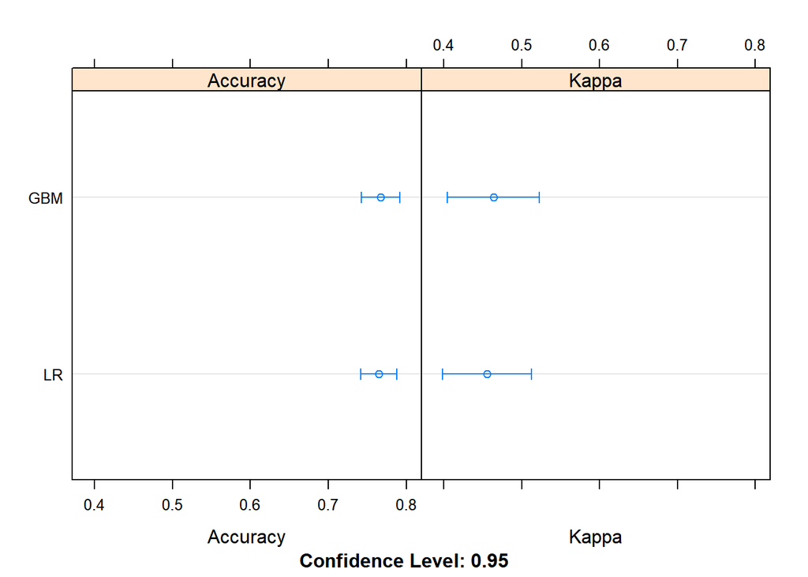

```r
dotplot(results)
```

## 6. Finalize Model and Present Results

Once we have narrow down to a model that we believe can make accurate predictions on unseen data, we are ready to finalize it. Finalizing a model may involve sub-tasks such as:

- Using an optimal model tuned to make predictions on unseen data.
- Creating a standalone model using the tuned parameters
- Saving an optimal model to file for later use.

```r
email_notify(paste("Model Validation and Final Model Creation has begun!",date()))
```

```
## [1] "Java-Object{org.apache.commons.mail.SimpleEmail@167fdd33}"
```

### 6.a) Predictions on validation dataset

```r
predictions <- predict(fit.final2, newdata=xy_test)
confusionMatrix(predictions, y_test)
```

```
## Confusion Matrix and Statistics
##
##           Reference
## Prediction pos neg
##        pos  45  20
##        neg  35 130
##
##                Accuracy : 0.7609
##                  95% CI : (0.7004, 0.8145)
##     No Information Rate : 0.6522
##     P-Value [Acc > NIR] : 0.000245
##
##                   Kappa : 0.4488
##  Mcnemar's Test P-Value : 0.059058
##
##             Sensitivity : 0.5625
##             Specificity : 0.8667
##          Pos Pred Value : 0.6923
##          Neg Pred Value : 0.7879
##              Prevalence : 0.3478
##          Detection Rate : 0.1957
##    Detection Prevalence : 0.2826
##       Balanced Accuracy : 0.7146
##
##        'Positive' Class : pos
##
```

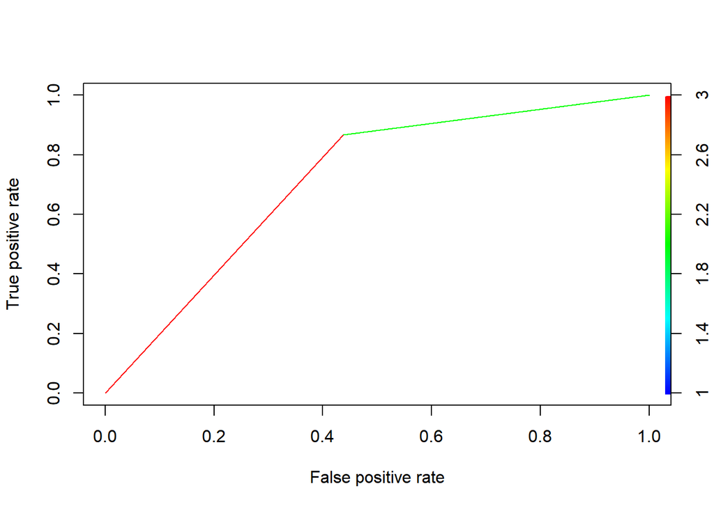

```r
pred <- prediction(as.numeric(predictions), as.numeric(y_test))
perf <- performance(pred, measure = "tpr", x.measure = "fpr")
plot(perf, colorize=TRUE)
```

```r
auc <- performance(pred, measure = "auc")
auc <- auc@y.values[[1]]
auc
```

```
## [1] 0.7145833
```

### 6.b) Create standalone model on entire training dataset

```r
startTimeModule <- proc.time()
library(gbm)
set.seed(seedNum)

# Combining the training and test datasets to form the original dataset that will be used for training the final model
xy_complete <- rbind(xy_train, xy_test)
xy_complete$targetVar <- 0
xy_complete$targetVar[xy_complete$oldTarget=="pos"] <- 1
xy_complete$oldTarget <- NULL

finalModel <- gbm(targetVar~., data=xy_complete, n.trees=100, shrinkage=0.1, interaction.depth=1, n.minobsinnode=10)
```

```
## Distribution not specified, assuming gaussian ...
```

```r
print(finalModel)
```

```
## gbm(formula = targetVar ~ ., data = xy_complete, n.trees = 100,
##     interaction.depth = 1, n.minobsinnode = 10, shrinkage = 0.1)
## A gradient boosted model with gaussian loss function.
## 100 iterations were performed.
## There were 8 predictors of which 0 had non-zero influence.
```

```r
proc.time()-startTimeModule
```

```
##    user  system elapsed
##    0.05    0.00    0.05
```

### 6.c) Save model for later use

```r
#saveRDS(finalModel, "./finalModel_BinaryClass.rds")
```

```r
email_notify(paste("Model Validation and Final Model Creation Completed!",date()))
```

```
## [1] "Java-Object{org.apache.commons.mail.SimpleEmail@74650e52}"
```

```r
proc.time()-startTimeScript
```

```
##    user  system elapsed
##   52.14    8.70  104.74
```